# GEO 812 – Tutorial 1: Data exploration

Author

Peter Ranacher & Takuya Takahashi

Published

September 12, 2024

# Learning Objectives

In this tutorial, you learn how to wrangle and visualise data in R using packages from the `tidyverse`. The tutorial has the following learning objectives:

- You are familiar with the `tidyverse`.
- You are able to explore, transform and visualize data in the `tidyverse`.

# Tibbles and the `tidyverse`

The [`tidyverse`](https://www.tidyverse.org/) is a collection of R packages designed for data science, sharing a common design philosophy, grammar, and data structure. The `tidyverse` makes it easy to perform data manipulation, visualisation, and analysis in a consistent way. Key packages in the `tidyverse` are `dplyr` for data manipulation and `ggplot2` for data visualisation. If you have not worked with R before, the `tidyverse` is arguably the easiest way to start. We first need to load the package to work with the `tidyverse`.

```r
library(tidyverse)
```

A tibble is the `tidyverse`’s way of storing observations of a phenomenon with several variables. In everyday language, we would refer to a tibble as a table. For those familiar with base R, tibbles are largely equivalent to data frames, with some added convenience functions. In this tutorial, we will work with two tibbles:

- `titanic_survival`: survival status of passengers on the Titanic
- `msleep`: sleep times and weights for selected mammalian species

The Titanic data comes with the `carData` package, which we need to load and convert into a tibble. The `msleep` data is included in the `tidyverse` package and is already in tibble format.

[figure not shown]

The Titanic. Before sinking.

```r
library(carData)
titanic_survival <- as_tibble(TitanicSurvival)
```

In a tibble, each variable is stored in its own column, each observation is in its own row, and each value is in its own cell. In other words, columns represent variables, while rows represent individual observations. This structure helps maintain clear and organised data.

The Titanic dataset consists of 1,309 observations (rows) and four variables (columns):

The Titanic survival data (first six rows)

| survived | sex | age | passengerClass |
| --- | --- | --- | --- |
| yes | female | 29.0000 | 1st |
| yes | male | 0.9167 | 1st |
| no | female | 2.0000 | 1st |
| no | male | 30.0000 | 1st |
| no | female | 25.0000 | 1st |
| yes | male | 48.0000 | 1st |

`survived` is the survival status of the passenger (`yes` or `no`). `sex` is the gender of the passenger; `age` is the age of the passenger; `passengerClass` is the class in which the passenger travelled;

The `msleep` data consist of 83 observations (rows) and eleven variables (columns).

The `msleep` data (first six rows)

[output not shown]

[figure not shown]

A fox during it’s 9.8 hours of total sleep per day.

# Transforming data

Next, you will learn how to explore, transform and manipulate data in a tibble. Specifically, you will

- `filter` observations by their values
- `select` variables by their names
- `arrange` the rows and order the observations
- `mutate` the data to create new variables from existing ones
- `summarise` the data by collapsing many values into a single value
- group the data with `group_by` and perform any of the above operations on the groups.

## `filter`

The [`filter`](https://dplyr.tidyverse.org/reference/filter.html) function is used to **subset rows** in a tibble based on specified conditions. For example, you can use it to select all Titanic passengers who were 25 years old at the time of the disaster.

```r
filter(titanic_survival, age == 25)
```

Similarly, you can use `filter` to identify all passengers who were younger than 25.

```r
filter(titanic_survival, age < 25)
```

The table below lists the most [common operators](https://stat.ethz.ch/R-manual/R-devel/library/base/html/Comparison.html) used to compare two values in a filter expression.

Operators for comparison.

| Operator | Description |
| --- | --- |
| == | equal |
| != | not equal |
| < | less than |
| <= | less than or equal |
| > | greater than |
| >= | greater than or equal |

```r
filter(msleep, !is.na(sleep_total))
```

You can combine `filter` expressions using logical operators. For example, you can filter for all carnivores that sleep longer than 11 hours.

```r
filter(msleep, vore == "carni" &  sleep_total > 11)
```

Alternatively, you can filter for all mammals that are either carnivores or omnivores.

```r
filter(msleep, vore == "carni" | vore == "omni")
```

The table below displays the three most important logical operators for combining `filter` expressions.

Logical Operators for combining filters.

| Operator | Description |
| --- | --- |
| & | Logical AND |
| \| | Logical OR |
| ! | Logical NOT |

## `select`

The [`select`](https://dplyr.tidyverse.org/reference/select.html) function is used to **subset columns** in a tibble based on specified column names. For example, you can use it to select only the `survived` and `age` columns from the Titanic dataset.

```r
select(titanic_survival, survived, age)
```

## `arrange`

The [`arrange`](https://dplyr.tidyverse.org/reference/arrange.html) function is used to **reorder rows** in a tibble based on the values of specified columns. For example, you can use it to order the Titanic survival data by `age` in ascending or descending order.

Order the data by `age` in ascending order:

```r
arrange(titanic_survival, age)
```

Order the data by `age` in descending order:

```r
arrange(titanic_survival, desc(age))
```

## `mutate`

The [`mutate`](https://dplyr.tidyverse.org/reference/mutate.html) function is used to **add new variables** or **transform existing variables** in a tibble. For example, you can use it to compute the ratio between REM sleep and total sleep in the mammal sleep data and assign it to a new variable called `rem_ratio`. Note that the new variable only exists in a temporary tibble created in this pipeline. To keep the tibble for later use, you would need to assign it to an object using the assignment operator (`<-`).

```r
mutate(msleep, rem_ratio = sleep_rem / sleep_total)
```

## `summarise`

The [`summarise`](https://dplyr.tidyverse.org/reference/summarise.html) function is used to **create a summary statistic** for a tibble. For example, you can use it to compute the mean age of passengers on the Titanic, removing `NA` values.

```r
summarise(titanic_survival, mean_age = mean(age, na.rm = TRUE))
```

Here are some useful summary functions you can use in `summarise`.

| Measures | Function | Description |
| --- | --- | --- |
| Measures of location | mean(x) | Mean |
|  | median(x) | Median |
| Measures of spread | sd(x) | Standard deviation |
|  | IQR(x) | Interquartile range |
|  | mad(x) | Median absolute deviation |
| Measures of rank | min(x) | Minimum |
|  | max(x) | Maximum |
|  | quantile(x, 0.95) | 95th quantile |
| Measures of position | first(x) | First row |
|  | nth(x, 2) | nth row |
|  | last(x) | Last row |
| Counts and proportions of logical values | n() | Count the number of rows |
|  | n_distinct(x) | Number of distinct combinations |
|  | sum(x > 10) | Sum of values larger than 10 |

## `group_by`

The [`group_by`](https://dplyr.tidyverse.org/reference/group_by.html) function is used to group a tibble by one or more variables. When used in conjunction with `summarise`, it computes the summary statistics within each group. Here’s an example computing the mean age of passengers, grouped by their class, removing `NA` values.

```r
group_by(titanic_survival, passengerClass) |>
  summarise(mean_age = mean(age, na.rm = TRUE))
```

## Combine operations

You might wonder what `|>` does in the code snippet above. `|>`, known as the [pipe operator](https://magrittr.tidyverse.org/reference/pipe.html), allows you to chain together multiple operations, passing the result of one operation as the input to the next , like Mario sliding through a pipe. For example, the code below filters out herbivores, then groups them by `order`, and finally computes the mean sleep and body weight per group all in one pipeline. Note that the `msleep` dataset is omitted from the subsequent operations because it has already been passed through the pipe. `|>` is a new pipe operator which was introduced quite recently. You may also see the old pipe operator `%>%` which works similarly.

```r
filter(msleep, vore == "herbi" ) |>
group_by(order) |>
  summarise(mean_sleep = mean(sleep_total, na.rm = TRUE),
            mean_bodywt = mean(bodywt, na.rm = TRUE))
```

[figure not shown]

The pipe operator (`|>`) works analogously to Mario sliding through a pipe from left to right, passing the result of one operation to the next.

## Join data

Sometimes we need to merge data from different tibbles into one. [Joins](https://dplyr.tidyverse.org/reference/mutate-joins.html) do just that. To perform a join, we first need a unique key to specify which rows should be matched.

Since we don’t have data that we can meaningfully join, we’ll use a made-up example to illustrate the concept. We’ll split the available data into two tibbles, each containing different subsets of columns but sharing a unique key. Once split, we use a join operation to combine these tibbles back together. For this purpose, we use `left_join`, which ensures that every row in the first tibble is preserved and matched with corresponding rows from the second tibble.

```r
# Add a unique ID
titanic_survival <- mutate(titanic_survival, id = row_number())

# Split the data into two tibbles
a <- select(titanic_survival, age, sex, id)
b <- select(titanic_survival, survived, passengerClass, id)

# Join the data back together again
left_join(a, b, by = "id")
```

# Plotting

`ggplot2` is the go-to package for visualising in the `tidyverse`. `ggplot2` builds on the [layered grammar of graphics](https://byrneslab.net/classes/biol607/readings/wickham_layered-grammar.pdf), which concisely describes the components of a graphic. You start by specifying the data and aesthetic mappings, such as which variables to plot on the x and y axes. Then, you add layers to the plot, with each layer introducing a specific type of visualization or statistical transformation, allowing you to build complex plots incrementally. Additionally, `ggplot2` offers extensive customisation options. Sounds complicated? Let’s walk through an example.

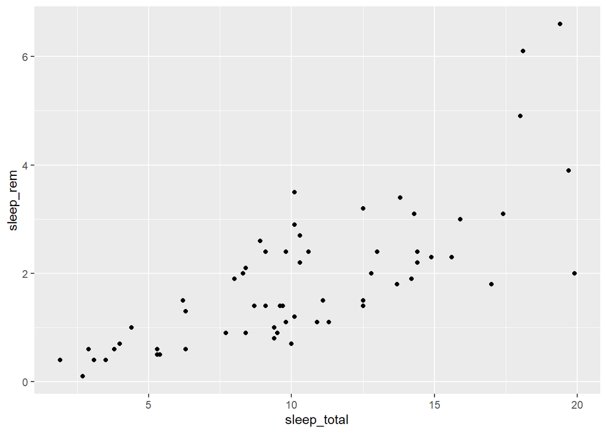

```r
ggplot(data = msleep) +
  geom_point(mapping = aes(x = sleep_total, y = sleep_rem))
```

`ggplot(data = msleep)` initializes the plot, specifying `msleep` as the dataset. The plus (`+`) operator adds a new layer to the plot; in this case, `geom_point` creates a plot where `sleep_total` is mapped to the x-axis and `sleep_rem` to the y-axis.

### Scatter plots

In the example above, [`geom_point`](https://ggplot2.tidyverse.org/reference/geom_point.html) creates a scatter plot, arguably one of the simplest types of plots. Scatter plots display individual data points on a two-dimensional plane, with each point representing a pair of values from two different variables. One variable is plotted on the x-axis and the other on the y-axis. The plot demonstrates the relationship between total sleep, plotted on the x-axis, and REM sleep, plotted on the y-axis. You can easily modify the [aesthetics](https://ggplot2.tidyverse.org/articles/ggplot2-specs.html) of the plot. For example, the code below color-codes the data points according to different `vores` and adjusts the size of the dots proportional to body weight.

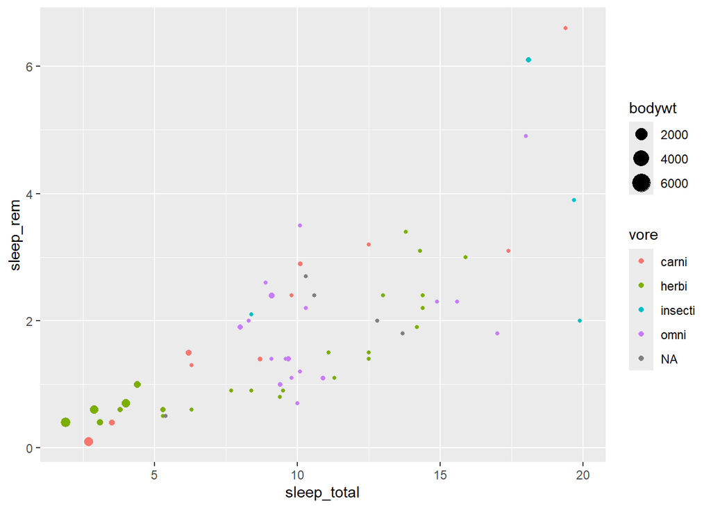

```r
ggplot(data = msleep) +
  geom_point(mapping = aes(sleep_total, sleep_rem,
                           color = vore,
                           size = bodywt))
```

### Bar plots

Another useful plot is a bar plot, which displays the magnitude of categories by using rectangular bars, where the length of each bar corresponds to the value of the category it represents. Here, we plot the number of passengers per class on the Titanic. `geom_bar` first groups the data by passenger class, counts the number of passengers per class, and then plots these counts as bars. Quite a lot is happening here behind the scenes!

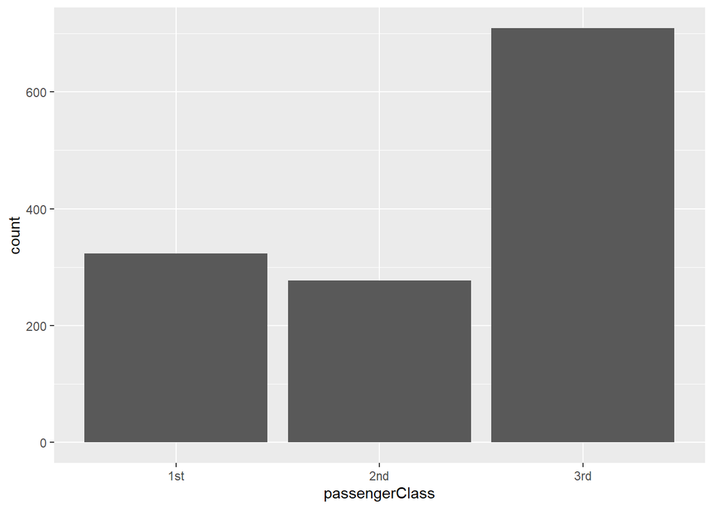

```r
ggplot(data = titanic_survival) +
  geom_bar(aes(x = passengerClass))
```

You can also modify the aesthetics of the bar plot by color-coding, for example, filling the bars according to survival status.

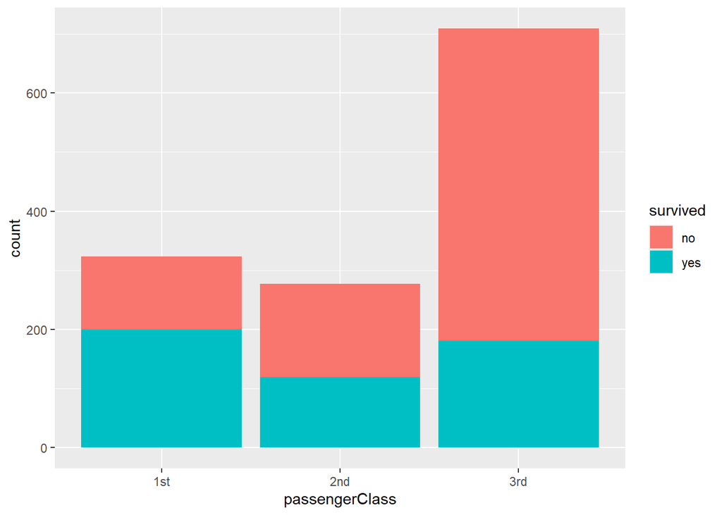

```r
ggplot(data = titanic_survival) +
  geom_bar(mapping = aes(passengerClass,
                         fill = survived))
```

# Cheat sheets

Here are two cheat sheets for data transformation and plotting in the `tidyverse`:

- [Data transformation](https://rstudio.github.io/cheatsheets/html/data-transformation.html)
- [Plotting in `ggplot2`](https://rstudio.github.io/cheatsheets/html/data-visualization.html)

# Exercise

1. Install and load the `gapminder` package, which provides values for life expectancy, GDP per capita, and population (gapminder illustration).
2. The data set contains data from multiple decades. Extract the data from the most recent year available.
3. Which 5 countries have the highest life-expectancy (in the most recent year)?
4. Which continent has the highest absolute GDP? Which has the highest GDP per capita? Beware that different countries have different population size.
5. Create a plot that shows GDP and life expectancy in different countries.
6. Add another visual variable (color, size, shape,…) to the plot (decide yourself what attribute of the data you want to show).

See you in the next tutorial!